# Exploratory data analysis on COVID-19 pandemic

#### 2. 2. 2. Growth factor

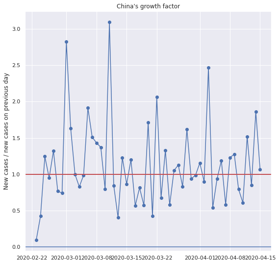

```python
yesterday = date.today() - timedelta(days = 1)

fig, ax = plot_growth_factor(by_date_china['23-02-2020':])
ax.set_title("China's growth factor")
plt.show()
```

**Observations:** Although the growth factor seems to be centering around one we are only working with a very little number of daily new cases compared to other countries as we can see below.

```python
past_week = date.today() - timedelta(days = 7)
new_cases_past_week = by_date_china[past_week:]['daily_confirmed'].mean()
print('There was an average of', int(new_cases_past_week), 'daily new cases in China last week')
```

```
There was an average of 74 daily new cases in China last week
```

#### 2. 2. 3. Active cases

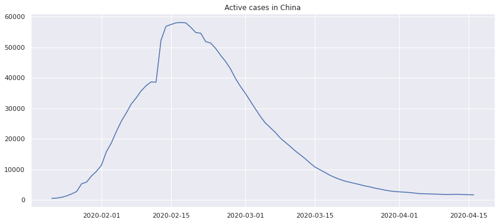

```python
fig, ax = plot_active_cases(by_date_china)
ax.set_title('Active cases in China')
plt.show()
```

**Observations:** The number of active cases has reduced drastically. As we will see from the following plot, in most cases the people have recovered.

#### 2. 2. 4. Outcome of cases

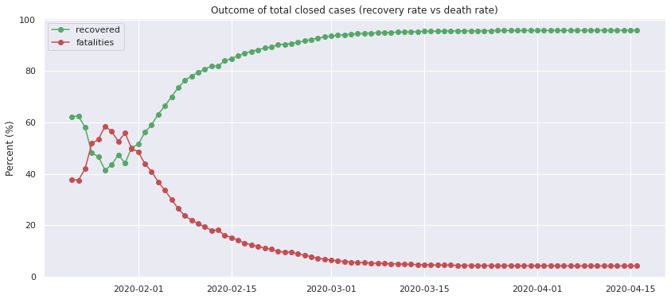

```python
fig, ax = plot_outcome_of_cases(by_date_china)
plt.show()
```

**Observations:** China looks to have handeled the pandemic well with very few deaths after the initial outbreak.

### 2. 3. Europe

We will be analysing Europe as whole. Though it is true that different measures were taken amongst european countries, we will be taking into consideration the geographical context, with the total EU area being smaller than US and China.

```python
european_countries = ['Austria',
                      'Belgium',
                      'Bulgaria',
                      'Croatia',
                      'Cyprus',
                      'Czech Republic',
                      'Denmark',
                      'Estonia',
                      'Finland',
                      'France',
                      'Germany',
                      'Greece',
                      'Hungary',
                      'Ireland',
                      'Italy',
                      'Latvia',
                      'Lithuania',
                      'Luxembourg',
                      'Malta',
                      'Netherlands',
                      'Poland',
                      'Portugal',
                      'Romania',
                      'Slovakia',
                      'Slovenia',
                      'Spain',
                      'Sweden']

by_date_eu = df[df.country.isin(european_countries)].groupby('date').sum()
```

#### 2. 3. 1. Total and daily cases

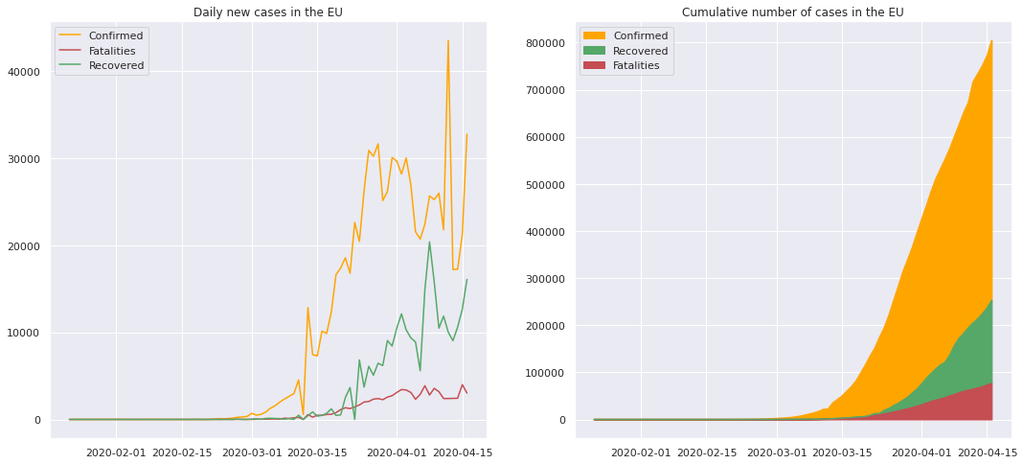

```python
fig, ax = plot_total_and_daily(by_date_eu)
ax[0].set_title('Daily new cases in the EU')
ax[1].set_title('Cumulative number of cases in the EU')
plt.show()
```

**Observations:** We can see how the new cases are starting to follow a downwards trend, on the other side the daily number of people recovered seems to follow a positive one while the fatalities are slightly increasing.

#### 2. 3. 2. Growth factor

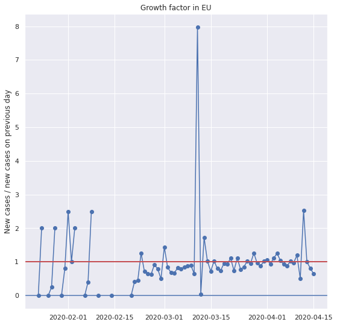

```python
fig, ax = plot_growth_factor(by_date_eu)
ax.set_title('Growth factor in EU')
plt.show()
```

#### 2. 3. 3. Active cases

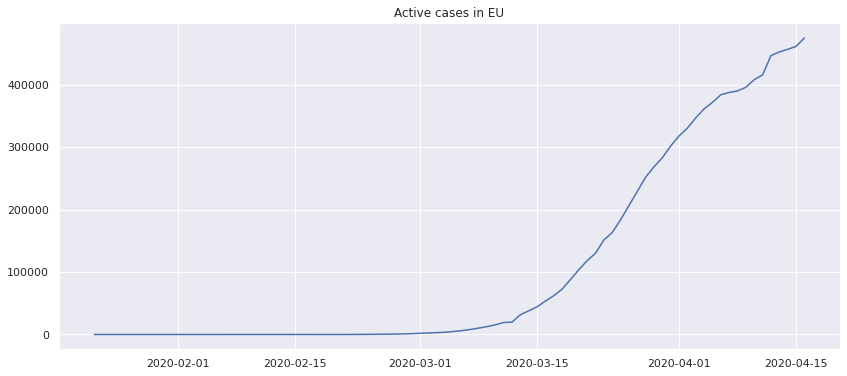

```python
fig, ax = plot_active_cases(by_date_eu)
ax.set_title('Active cases in EU')
plt.show()
```

**Observations:**

#### 2. 3. 4. Outcome of cases

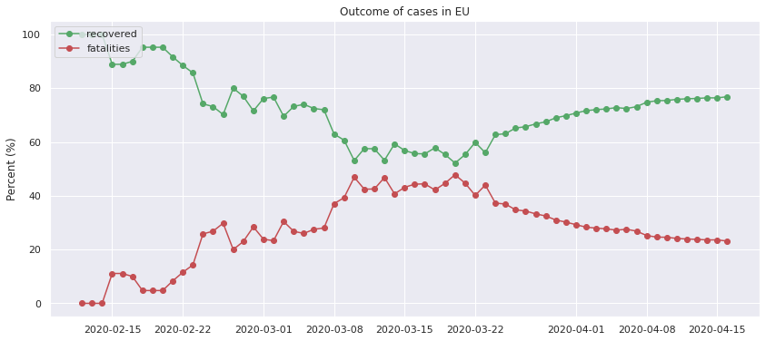

```python
fig, ax = plot_outcome_of_cases(by_date_eu)
ax.set_title('Outcome of cases in EU')
plt.show()
```

**Observations:** In the later stages there seems to be a steady increase in the number of people recovered.

### 2. 4. USA

```python
by_date_usa = df[df.country=='US'].groupby('date').sum()
```

#### 2. 4. 1. Total and daily cases

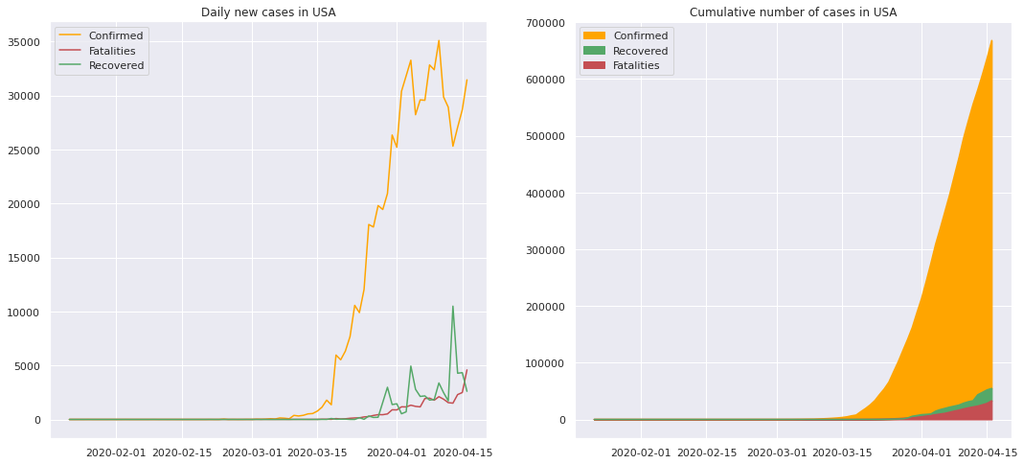

```python
fig, ax = plot_total_and_daily(by_date_usa)
ax[0].set_title('Daily new cases in USA')
ax[1].set_title('Cumulative number of cases in USA')
plt.show()
```

#### 2. 4. 2. Growth factor

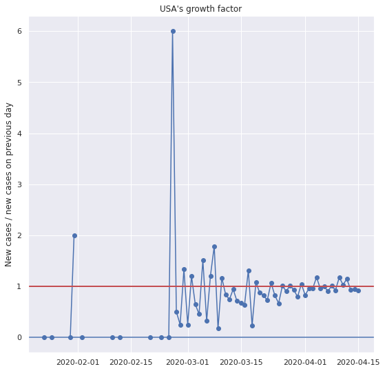

```python
fig, ax = plot_growth_factor(by_date_usa)
ax.set_title("USA's growth factor")
plt.show()
```

**Observations:** As the datapoints are all very close to one we are still at an exponential increase in new cases.

#### 2. 4. 3. Active cases

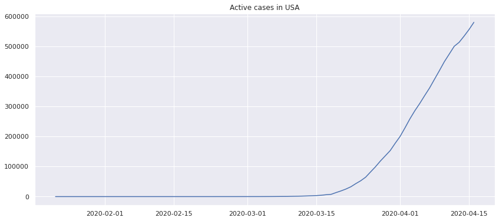

```python
fig, ax = plot_active_cases(by_date_usa)
ax.set_title('Active cases in USA')
plt.show()
```

**Observations:** Also the number of active cases is increasing steeply.

#### 2. 4. 4. Outcome of cases

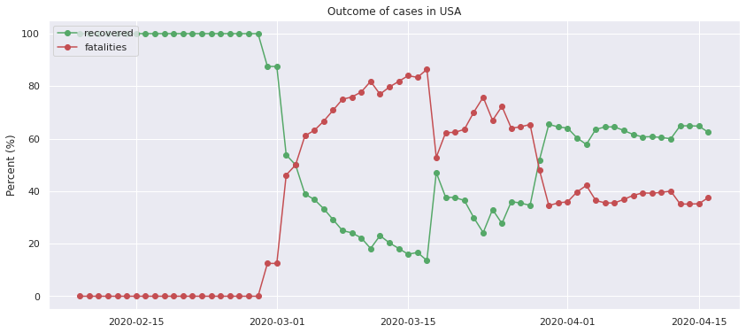

```python
fig, ax = plot_outcome_of_cases(by_date_usa)
ax.set_title('Outcome of cases in USA')
```

## 3. **Disclaimer**

- With new data being added on a daily basis, in order to include the most recent cases, some sections might not be up to date.
- The objective of this notebook is to provide some insights about the COVID-19 transmission from a data-centric perspective in a didactical and simple way. Results should not be considered in any way an affirmation of what will happen in the future. Observations obtained from data exploration are personal opinions.